# Rmd Exercise Template

2019-09-18

## Load the data

Load the `gapminder` dataset.

```r
gapminder <- read.csv(here::here("data", "gapminder5.csv"), stringsAsFactors = FALSE)
```

## If Statement

Use an if() statement to print a suitable message reporting whether there are any records from 2002 in the gapminder dataset. Now do the same for 2012.

Hint: use the `any` function.

```r
check_year <- 2002
if (any(gapminder$year == check_year)) {
    print(paste('Records from year', check_year, 'exists.'))
} else {
    print(paste('Records from year', check_year, 'do not exist.'))
}
```

```
## [1] "Records from year 2002 exists."
```

```r
check_year <- 2012
if (any(gapminder$year == check_year)) {
    print(paste('Records from year', check_year, 'exists.'))
} else {
    print(paste('Records from year', check_year, 'do not exist.'))
}
```

```
## [1] "Records from year 2012 do not exist."
```

## Loop and If Statements

Write a script that finds the mean life expectancy by country for countries whose population is below the mean for the dataset.

```r
mean_pop_overall <- mean(gapminder$pop, na.rm = TRUE)
countries <- unique(gapminder$country)

for (i in countries) {
    mean_pop_country <- mean(gapminder$pop[gapminder$country == i], na.rm = TRUE)
    if (mean_pop_country < mean_pop_overall) {
        mean_exp_country <- mean(gapminder$lifeExp[gapminder$country == i], na.rm = TRUE)
        print(paste('Mean life expectancy in', i, 'is', mean_exp_country))
    }
}
```

```
## [1] "Mean life expectancy in Afghanistan is 37.4788333333333"
## [1] "Mean life expectancy in Albania is 68.4329166666667"
## [1] "Mean life expectancy in Algeria is 59.0301666666667"
## [1] "Mean life expectancy in Angola is 37.8835"
## [1] "Mean life expectancy in Argentina is 69.0604166666667"
## [1] "Mean life expectancy in Australia is 74.6629166666667"
## [1] "Mean life expectancy in Austria is 73.10325"
## [1] "Mean life expectancy in Bahrain is 65.6056666666667"
## [1] "Mean life expectancy in Belgium is 73.64175"
## [1] "Mean life expectancy in Benin is 48.7799166666667"
## [1] "Mean life expectancy in Bolivia is 52.5045833333333"
## [1] "Mean life expectancy in Bosnia and Herzegovina is 67.7078333333333"
## [1] "Mean life expectancy in Botswana is 54.5975"
## [1] "Mean life expectancy in Bulgaria is 69.74375"
## [1] "Mean life expectancy in Burkina Faso is 44.694"
```

[output cut: 100 more lines]

Write a script that loops through the `gapminder` data by continent and prints out whether the mean life expectancy is smaller than 50, between 50 and 70, or greater than 70.

```r
continents <- unique(gapminder$continent)

for (i in continents) {
    mean_exp_cont <- mean(gapminder$lifeExp[gapminder$continent == i], na.rm = TRUE)
    if (mean_exp_cont < 50) {
        print(paste('Mean life expectancy in', i, 'is smaller than 50.'))
    } else if (mean_exp_cont > 70) {
        print(paste('Mean life expectancy in', i, 'is greater than 70.'))
    } else {
        print(paste('Mean life expectancy in', i, 'is between 50 and 70.'))
    }
}
```

```
## [1] "Mean life expectancy in Asia is between 50 and 70."
## [1] "Mean life expectancy in Europe is greater than 70."
## [1] "Mean life expectancy in Africa is smaller than 50."
## [1] "Mean life expectancy in Americas is between 50 and 70."
## [1] "Mean life expectancy in Oceania is greater than 70."
```

## Exercise: Write Functions

Create a function that given a data frame will print the name of each column and the class of data it contains. Use the gapminder dataset. Hint: Use `mode()` or `class()` to get the class of the data in each column. Remember that `names()` or `colnames()` returns the name of the columns in a dataset.

```r
report_df <-
    function(df) {
        for (i in names(df)) {
            col_class <- class(df[[i]])
            print(paste0(i, ': ', col_class))
        }
    }
report_df(gapminder)
```

```
## [1] "country: character"
## [1] "year: integer"
## [1] "pop: numeric"
## [1] "continent: character"
## [1] "lifeExp: numeric"
## [1] "gdpPercap: numeric"
```

Create a function that given a vector will print the mean and the standard deviation of a **vector**, it will optionally also print the median. Hint: include an argument that takes a boolean (`TRUE`/`FALSE`) operator and then include an `if` statement.

```r
report_mean_sd <-
    function(vec, print_median = FALSE) {
        vec_mean <- mean(vec, na.rm = TRUE)
        print(paste('mean:', vec_mean))
        vec_sd <- sd(vec, na.rm = TRUE)
        print(paste('standard deviation:', vec_sd))
        if (print_median) {
            vec_median <- sd(vec, na.rm = TRUE)
            print(paste('median:', vec_median))
        }
    }

report_mean_sd(gapminder$lifeExp, print_median = FALSE)
```

```
## [1] "mean: 59.4744393661972"
## [1] "standard deviation: 12.9171074152412"
```

```r
report_mean_sd(gapminder$lifeExp, print_median = TRUE)
```

```
## [1] "mean: 59.4744393661972"
## [1] "standard deviation: 12.9171074152412"
## [1] "median: 12.9171074152412"
```

## Analyzing the relationship between GDP per capita and life expectancy

Use what you’ve learned so far to answer the following questions using the `gapminder` dataset. Be sure to include some visualizations!

1. What is the relationship between GDP per capita and life expectancy? Does this relationship change over time? (Hint: Use the natural log of both variables.)

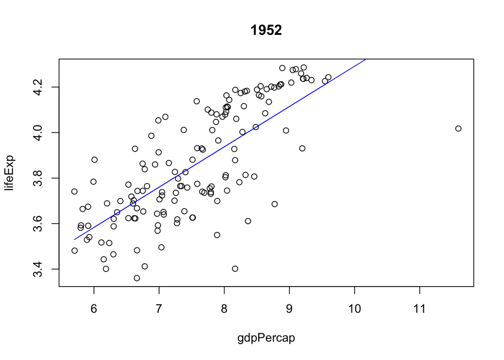

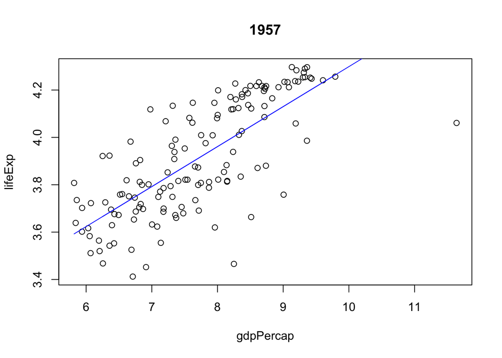

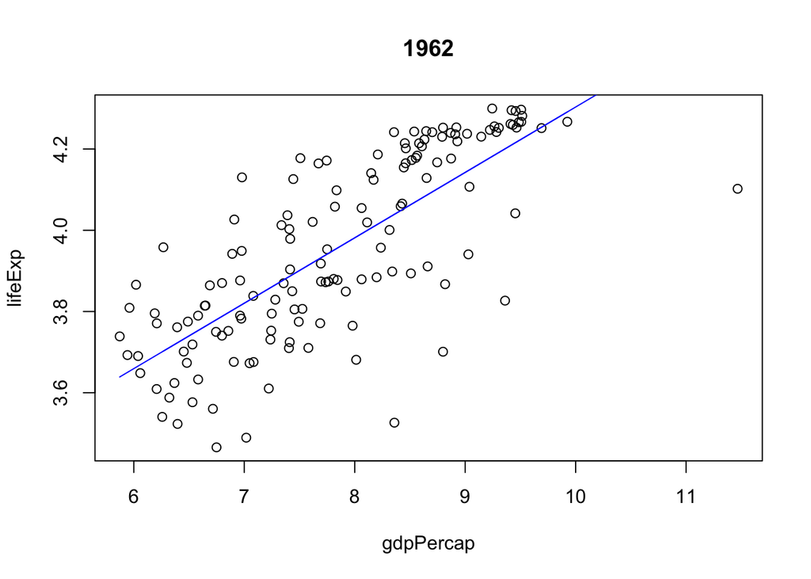

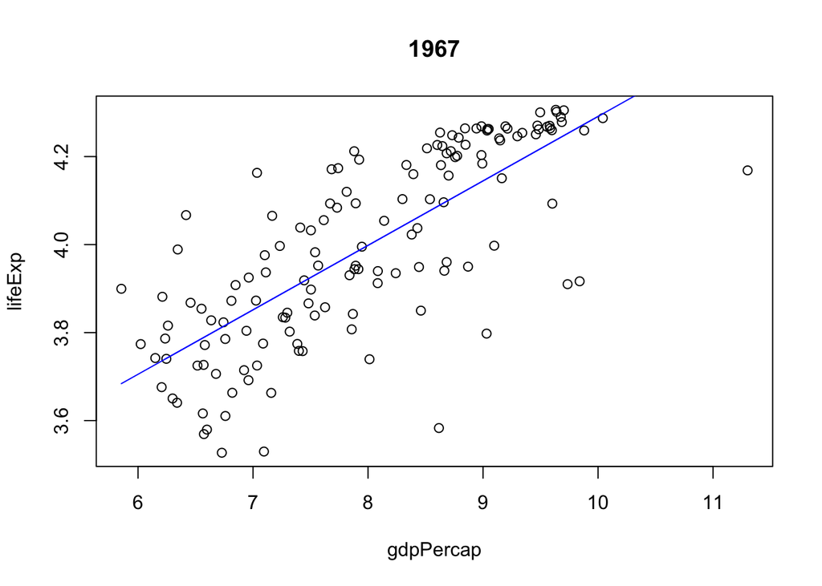

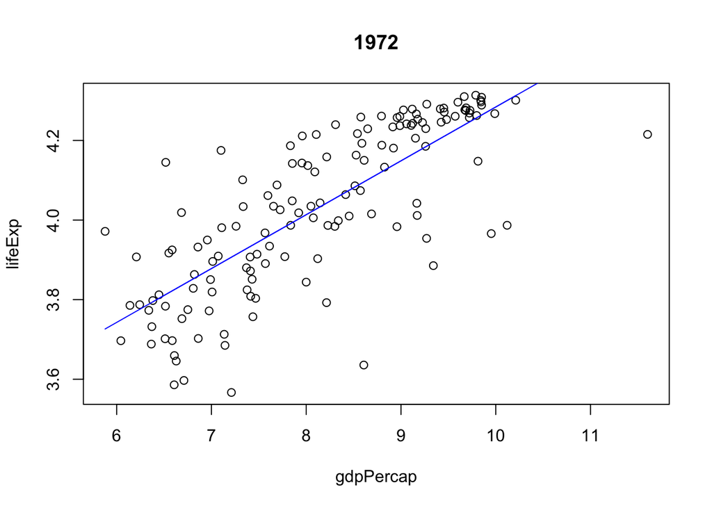

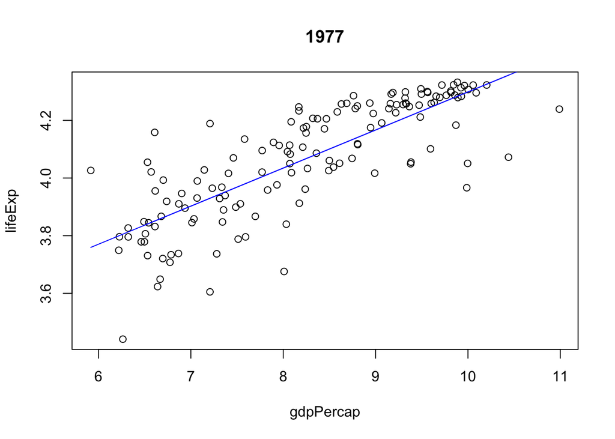

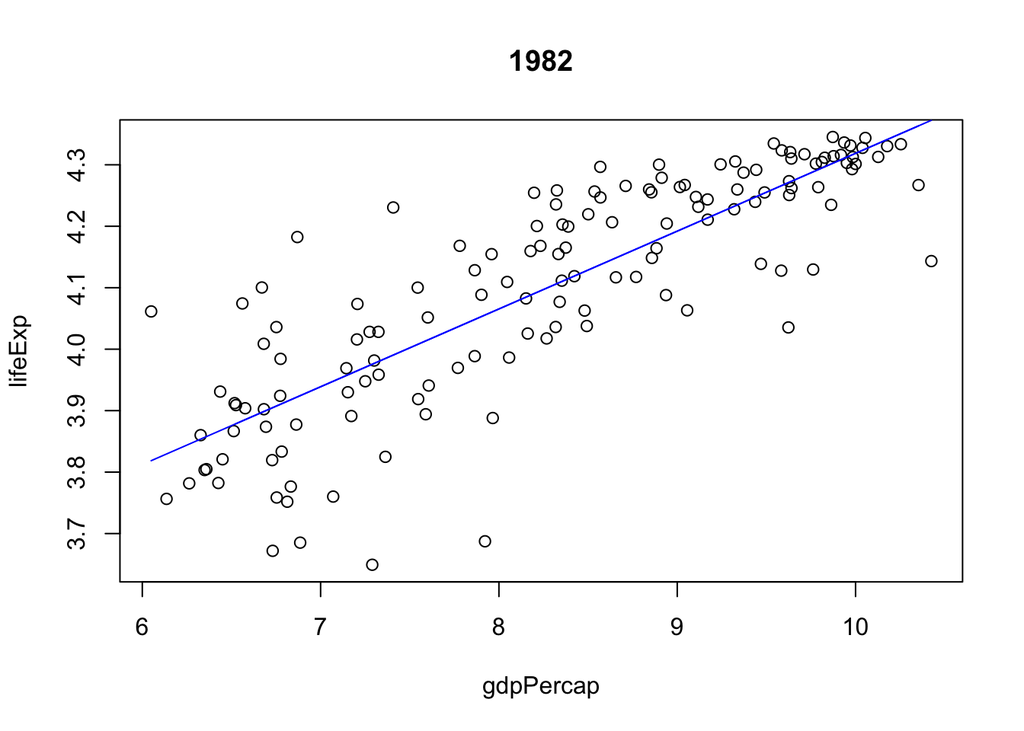

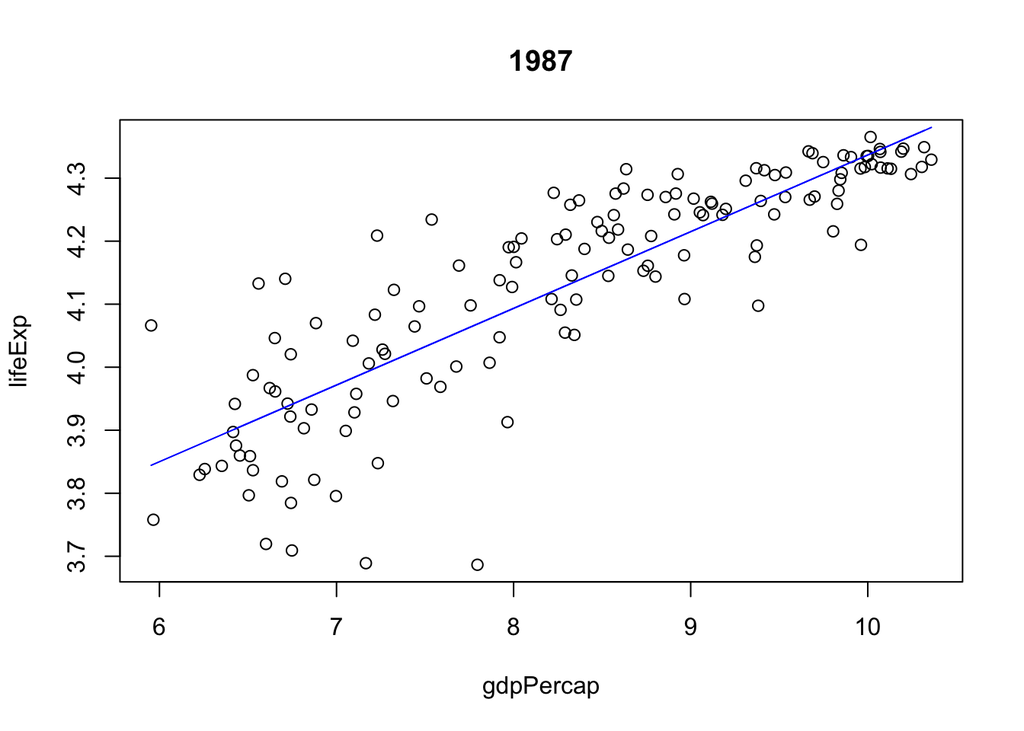

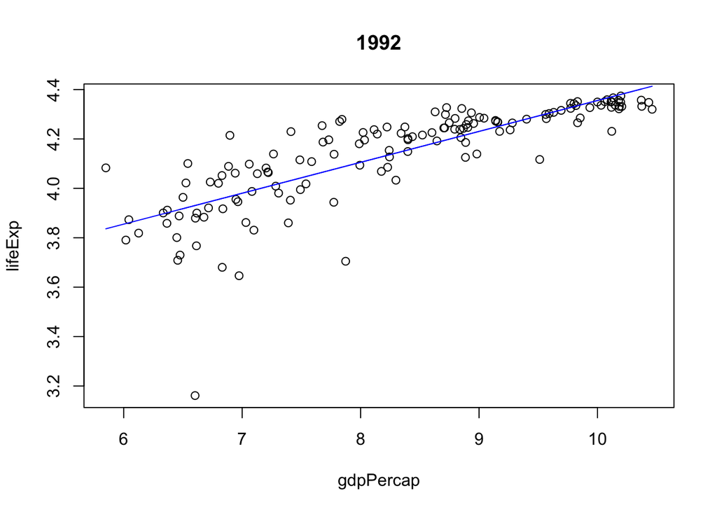

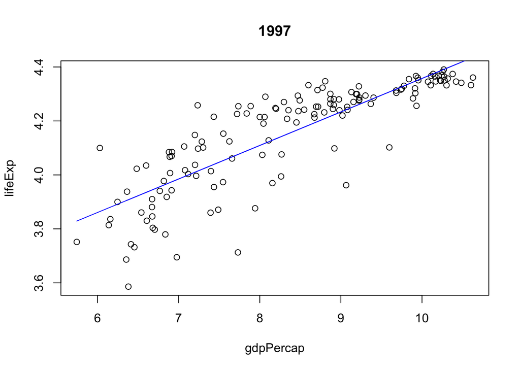

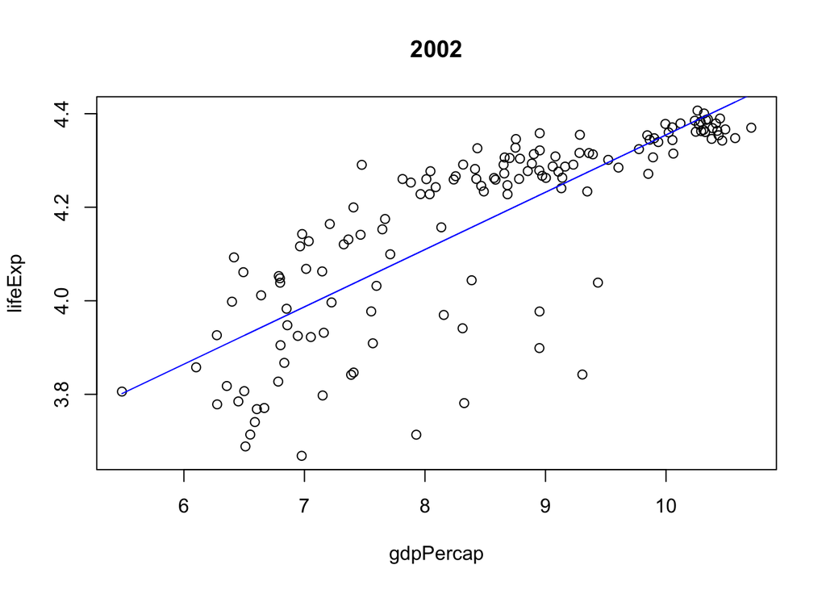

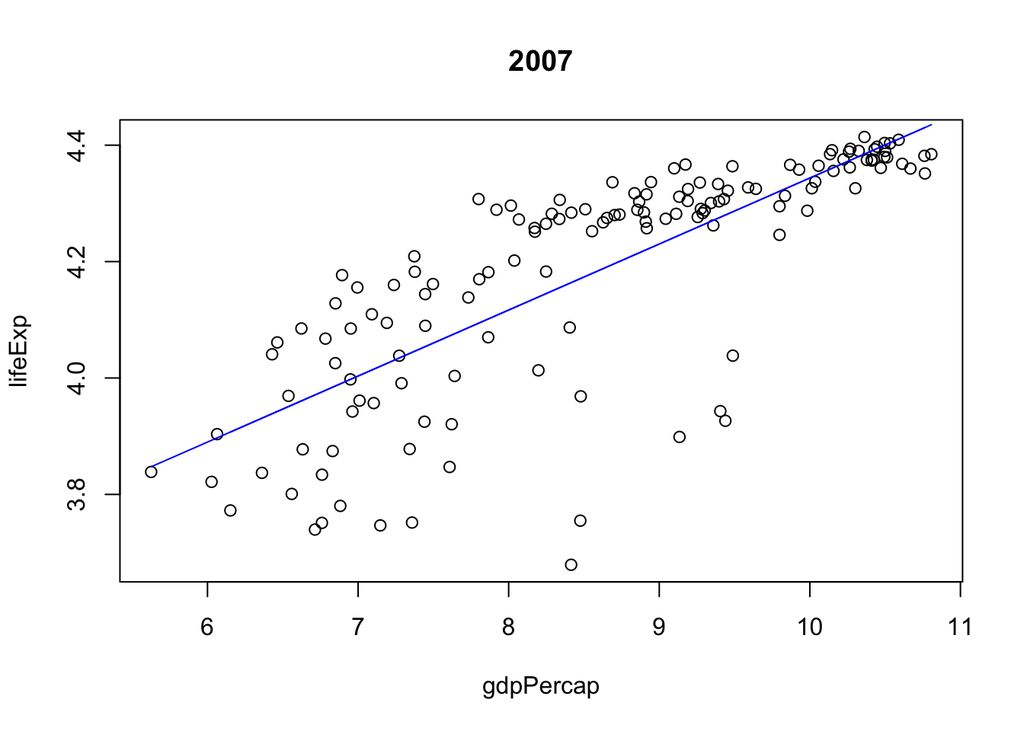

```r
# write a function to plot the relationship based on GDP per capita, life expectancy and year
viz_lm <-
  function(df, dv, iv, year) {
    dat <- df[df[["year"]] == year, ]
    y <- log(dat[[dv]])
    x <- log(dat[[iv]])
    fit <- lm(y ~ x)
    plot(y ~ x, main = year, xlab = iv, ylab = dv)
    lines(x, predict(fit), col = 'blue')
  }

# loop the function above through years
for (i in unique(gapminder$year)) {
    viz_lm(gapminder, 'lifeExp', 'gdpPercap', i)
}
```

The graphs above show that, over years, GDP per capita and life expectancy have always been positively correlated with each other. We expect that countries with higher GDP per capita have a higher life expectancy, and countries with lower GDP per capita have a lower life expectancy.

2. Does the relationship between GDP per capita and life expectacy vary by continent? Make sure you divide the Americas into North and South America.

```r
north_america_countries <- c('Canada', 'United States', 'Mexico')

# use a new continent variable and loop through observations to redivide the continents
gapminder$new_continent <- NA
for (i in 1:dim(gapminder)[1]) {
    if (gapminder$country[i] %in% north_america_countries) {
        gapminder$new_continent[i] <- 'North America'
    } else {
        if (gapminder$continent[i] == 'Americas') {
            gapminder$new_continent[i] <- 'South America'
        } else {
            gapminder$new_continent[i] <- gapminder$continent[i]
        }
    }
}
```

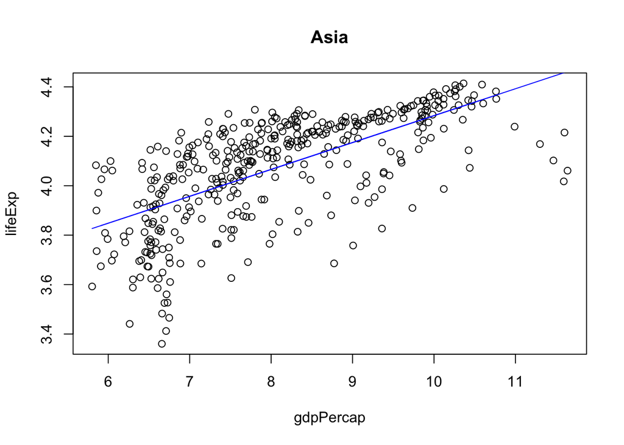

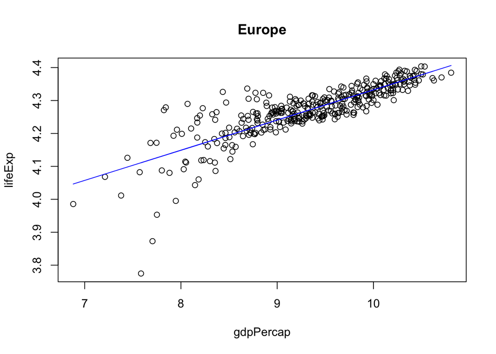

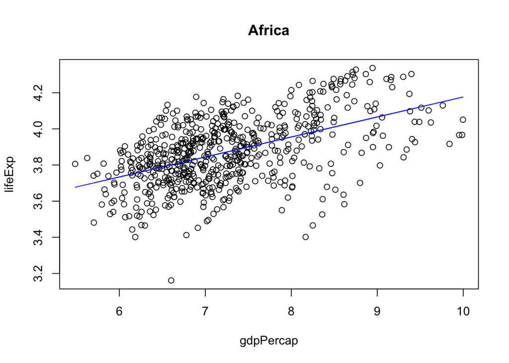

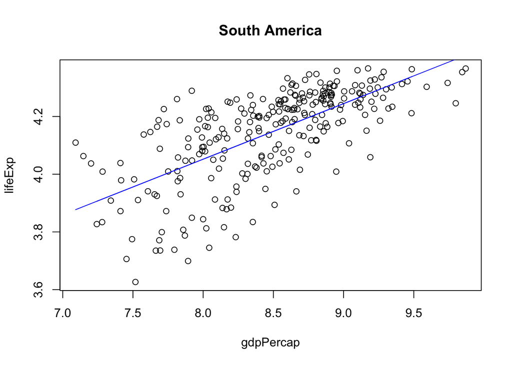

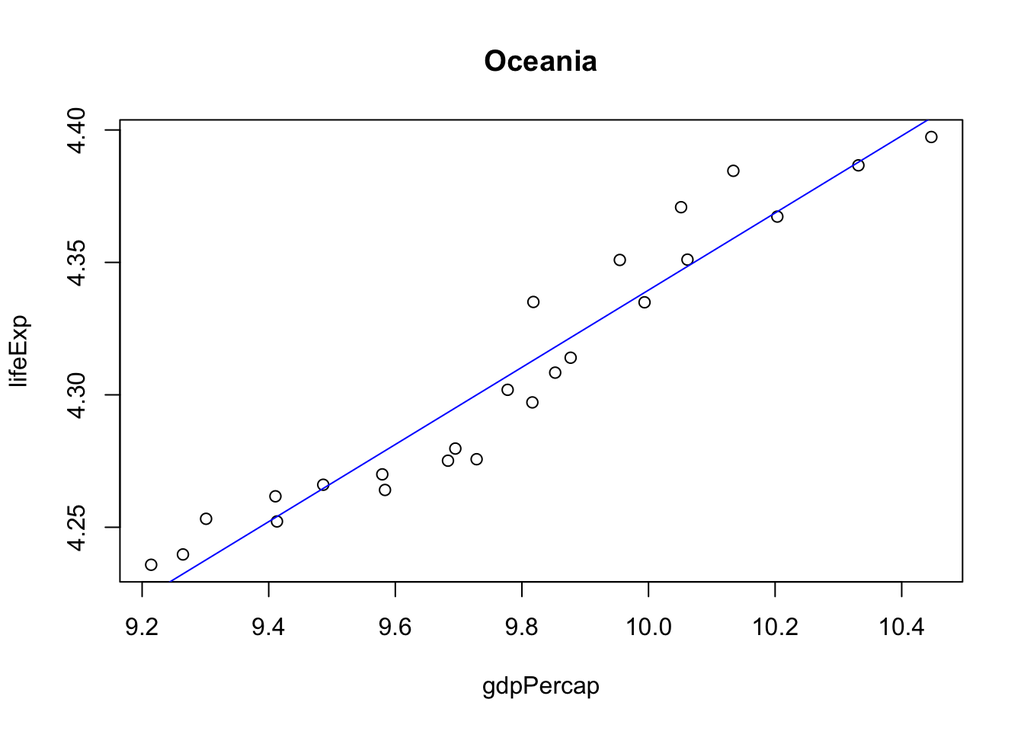

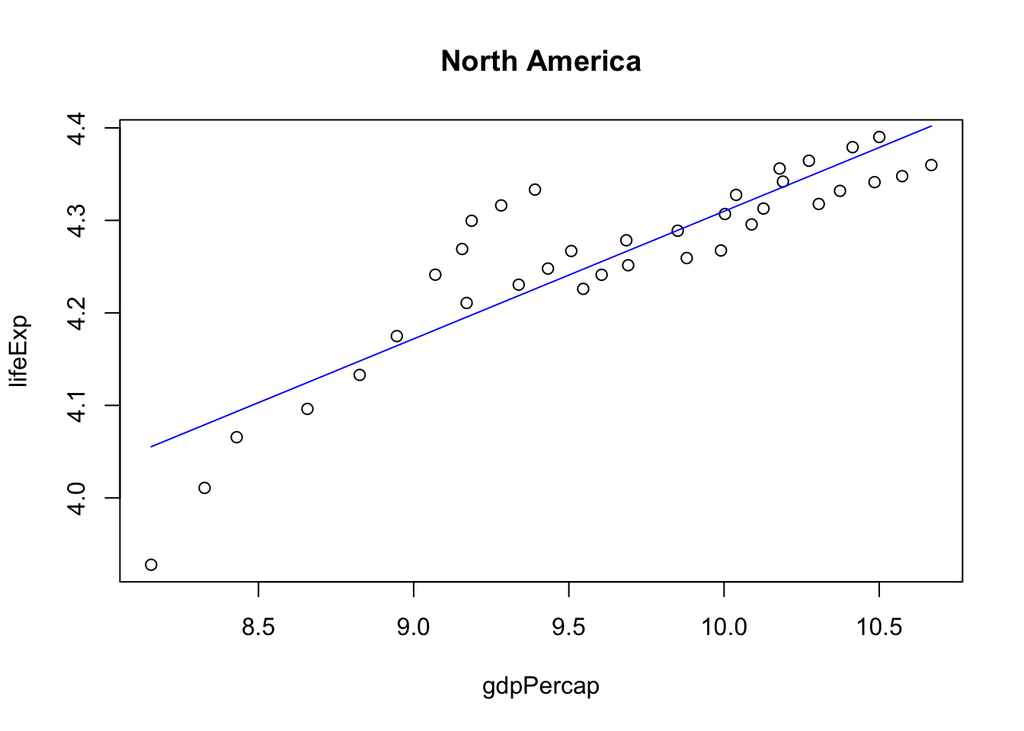

```r
# write a function to plot the relationship based on GDP per capita, life expectancy and continent
viz_lm_cont <-
  function(df, dv, iv, cont) {
    dat <- df[df[["new_continent"]] == cont, ]
    y <- log(dat[[dv]])
    x <- log(dat[[iv]])
    fit <- lm(y ~ x)
    plot(y ~ x, main = cont, xlab = iv, ylab = dv)
    lines(x, predict(fit), col = 'blue')
  }

# loop the function above through continents
for (i in unique(gapminder$new_continent)) {
    viz_lm_cont(gapminder, 'lifeExp', 'gdpPercap', i)
}
```